# Practical Report 9

# Effectiveness of blood pressure treatment

We begin with the model from Practical 7, that is
$$\begin{align*}
{\mathbb E}[\texttt{BPchange}_i]\quad = \quad
\beta_0+\beta_1\texttt{BPinit}_i+\beta_2\texttt{Dose}_i, \qquad
\mbox{where } i=1, \ldots, 40.
\end{align*}$$

```r
bpdata <- read.csv("../data/bpdata.csv")
lm.out1 <- lm(BPchange ~ BPinit + Dose, data=bpdata)
```

## Part a

We perform the test by `anova` between null model and `lm.out1`.

```r
# Fit null model
lm.out0 <- lm(BPchange ~ 1, data=bpdata)
# Use the anova function with two arguments
anova(lm.out0, lm.out1)
```

|  | Res.Df | RSS | Df | Sum of Sq | F | Pr(>F) |
| --- | --- | --- | --- | --- | --- | --- |
| 1 | 39 | 261.77500 | NA | NA | NA | NA |
| 2 | 37 | 42.24838 | 2 | 219.5266 | 96.12777 | 2.217252e-15 |

The table we want is

| Source | d.f. | SS | MS | F |
| --- | --- | --- | --- | --- |
| Regression | 2 | $\sum_{i=1}^{n} (\hat{y}_i - \bar{y})^2$ | $\frac{\text{RegrSS}}{p-1}$ | 96.128 |
| Residual | 37 | $\sum_{i=1}^{n} (y_i - \hat{y}_i)^2$ | $\frac{\text{ResidSS}}{n-p}$ |  |
| Total | 39 | $\sum_{i=1}^{n} (y_i - \bar{y})^2$ |  |  |

The output gives the observed $F$-statistic and $p$-value but we still need to compute the mean squares and sum of squares to construct the full ANOVA table for the existence of regression.

From the table, we know directly that residual sum of squares (ResidSS) is
$$\sum_{i=1}^n (y_i - \hat{y}_i)^2 = 42.248,$$
and the regression sum of squares (RegrSS) is
$$\begin{align*}
\sum_{i=1}^n (\hat{y}_i - \bar{y})^2 &= \sum_{i=1}^n (y_i -
\bar{y})^2 - \sum_{i=1}^n (y_i - \hat{y}_i)^2\\
&= \text{ResidSS of Model 1} - \text{ResidSS of Model 2}\\
&= 261.775 - 42.248 = 219.527
\end{align*}$$

For the mean squares, we have

- ${\rm RegrMS} = \frac{{\rm RegrSS}}{{\rm df(RegrSS)}} = \frac{219.527}{2} = 109.762,$
- ${\rm ResidMS} = \frac{{\rm ResidSS}}{{\rm df(ResidSS)}} = \frac{42.248}{37} = 1.142,$

Recall that the test for existence of regression is based on
$$\begin{align*}
H_0:\: \beta_1=\beta_2=0 \qquad \text{vs} \qquad
H_1:\: \mbox{ at least one of } \beta_1,\beta_2 \mbox{ is non-zero}.
\end{align*}$$
We have $n=40$ and $p=3$ from data and model parameters. Thus, under $H_0$, $F \sim F_{p-1,n-p} = F_{2, 37}$. We can calculate the p-value given by $P(F_{2, 37} \geq F_{\rm obs})$ where $F_{\rm obs}=96.128$ and obtain 2.22e-15 which is substantially smaller than the significance level of 5%. Thus we have very strong evidence to reject $H_0$. We conclude that at least one of the two explanatory variables, that is the initial blood pressure (`BPinit`) and the dosage of the new drug (`Dose`), are informative about the change in blood pressure (`BPchange`).

## Part b

The `anova()` function with one argument produces a sequential ANOVA which shows what happens when, starting from the null model (with only the intercept), we add the terms of the model sequentially from left to right. If the formula is
$$\begin{align*}
{\tt BPchange \quad \sim \quad BPinit + Dose}
\end{align*}$$
when the `R` output shows the effect of adding `BPinit` then `Dose`.

```r
anova(lm.out1)
```

|  | Df | Sum Sq | Mean Sq | F value | Pr(>F) |
| --- | --- | --- | --- | --- | --- |
| BPinit | 1 | 47.21377 | 47.213775 | 41.34856 | 1.645788e-07 |
| Dose | 1 | 172.31285 | 172.312845 | 150.90698 | 1.269460e-14 |
| Residuals | 37 | 42.24838 | 1.141848 | NA | NA |

## Part c

By controlling for initial blood pressure, this question is asking the effect of new drug on blood pressure. This is the same as asking about the significance of the parameter for the `Dose` term. Hence, we can apply a hypothesis test as
$$\begin{align*}
H_0:\: \beta_2 = 0 \quad \text{versus} \quad
H_1:\: \beta_2 \neq 0.
\end{align*}$$
As `Dose` was entered second in the model, this test is reported on in the sequential ANOVA in the row corresponding to `Dose`. As the $p$-value is less than 0.001, there is very strong evidence to reject $H_0$. We thus conclude that, controlling for initial blood pressure, the new drug has an effect on blood pressure.

We can also use a $t$-test which is reported on in the summary output of the model. In fact, this two-sided $t$-test is equivalent to the partial $F$-test reported on in the sequential ANOVA. The observed $T$-statistic is equal to `-12.284` with a $p$-value of `1.27e-14`. (Note that the square of the observed $T$-statistic is equal to the observed $F$-statistic and they both have the same $p$-value.)

```r
summary(lm.out1)
```

```
Call:
lm(formula = BPchange ~ BPinit + Dose, data = bpdata)

Residuals:
     Min       1Q   Median       3Q      Max
-2.00688 -0.60590  0.02509  0.75888  2.30379

Coefficients:
             Estimate Std. Error t value Pr(>|t|)
(Intercept) -1.962512   0.910702  -2.155  0.03774 *
BPinit      -0.021542   0.006269  -3.436  0.00147 **
Dose        -0.190743   0.015527 -12.284 1.27e-14 ***
---
Signif. codes:  0 '***' 0.001 '**' 0.01 '*' 0.05 '.' 0.1 ' ' 1

Residual standard error: 1.069 on 37 degrees of freedom
Multiple R-squared:  0.8386,    Adjusted R-squared:  0.8299
F-statistic: 96.13 on 2 and 37 DF,  p-value: 2.217e-15
```

## Part d

For the degrees of freedom column, we get:

- The total degrees of freedom is the sum of all 3 entries in the column labelled “Df”:  
  $(39 = 1 + 1 + 37)$
- The regression degrees of freedom is the sum of the two rows for the terms `Dose` and `BPinit`: $(2 = 1 + 1)$
- The residual degrees of freedom is from the third row labelled “Residuals”: $37$.

For the sum of squares column, we get:

- The total sum of squares is the sum of all 3 entries in the column labelled “Sum Sq”: $(261.775 = 47.214 + 172.313 + 42.248).$
- The regression sum of squares is the sum of the two rows for the terms `Dose` and `BPinit`: $(219.527 = 47.214 + 172.313).$
- The residual sum of squares is from the third row labelled “Residuals” (42.248.)

Hence, the $F$-statistic can be computed as

- ${\rm RegrMS} = \frac{{\rm RegrSS}}{{\rm df(RegrSS)}} = \frac{219.527}{2} = 109.762,$
- ${\rm ResidMS} = \frac{{\rm ResidSS}}{{\rm df(ResidSS)}} = \frac{42.248}{37} = 1.142,$
- ${F}_{\rm obs} = \frac{\rm RegrMS}{\rm ResidMS} = \frac{109.762}{1.142} = 96.128.$

# Model selection statistics

In Experiment 1 we generate data for 50 predictor variables $X_1, \ldots, X_{50}$ all of which are non-informative about the response $Y$ as the latter is sampled independently from the predictor variables. We then consider a sequence of models, starting with a simple linear regression of $Y$ on $X_1$ and adding the other predictor variables one at a time. For each model the coefficient of determination $R^2$ is computed. The plot below shows the resulting sequence of $R^2$ values.

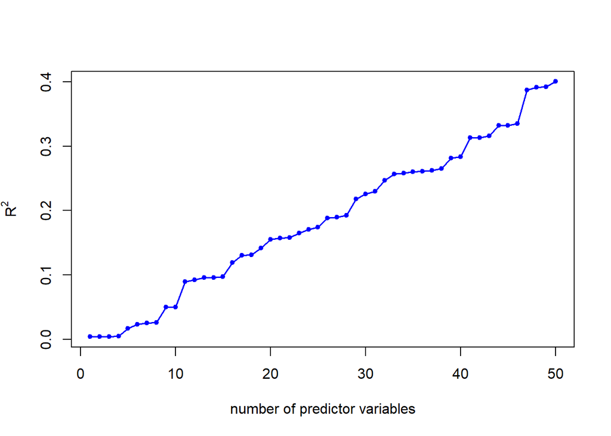

Figure 1: A graphical illustration of the coefficient of determination as the number of non-informative predictor variables increases in the model.

```r
# Generate data
set.seed(22)
x <- matrix(rnorm(5000),100,50)
y <- rnorm(100)
data <- as.data.frame(cbind(y,x))
# Fit linear regression models with increasing number of variables
r2 <- rep(NA,50)
for (j in 1:50){
  data_temp <- data[ ,1:(j+1)]
  r2[j] <- summary(lm(y ~ ., data=data_temp))$r.squared
}
# Plot the sequence of R^2 statistics
plot(r2,type="l",lwd=1.5,col="blue",
     xlab="number of predictor variables",ylab=expression(R^2))
points(r2,col="blue",pch=20)
```

We observe that despite the predictor variables all being non-informative about the response, the coefficient of determination $R^2$ continues to increase as we add more predictor variables to the model.

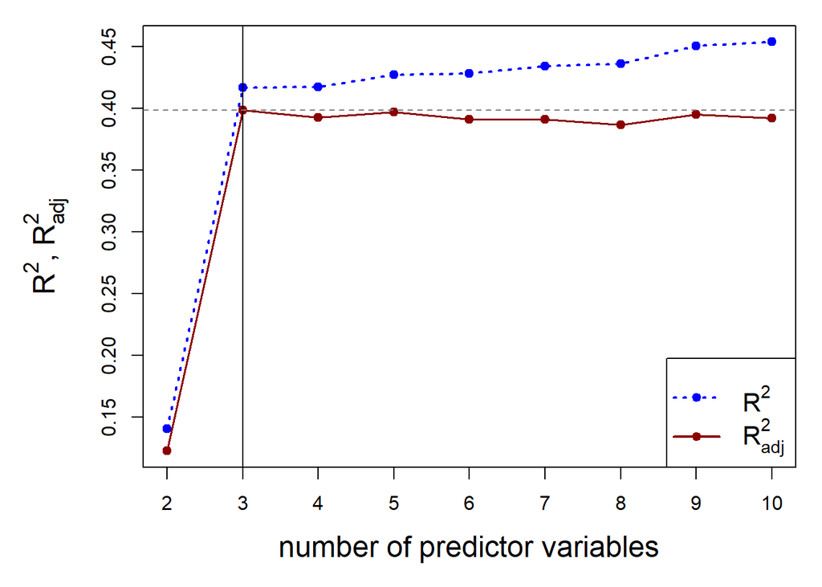

Figure 2: A graphical illustration of the difference of behaviour between the coefficient of determination and the adjusted coefficient of determination as the number of predictor variables increases in the model.

```r
# Generate data
set.seed(13)
x <- matrix(rnorm(1000),100,10)
y <- rnorm(100) + 1 + 0.25*x[,1] + 0.5*x[,2] + 0.5*x[,3]
data <- as.data.frame(cbind(y,x))
# Fit linear regression models with increasing number of variables
r2 <- rep(NA,10)
r2adj <- rep(NA,10)
for (j in 1:10){
data_temp<-data[,1:(j+1)]
r2[j] <- summary(lm(y ~ ., data=data_temp))$r.squared
r2adj[j] <- summary(lm(y ~ ., data=data_temp))$adj.r.squared
}
# Adjust margins of plotting region
par(mar=c(5,6,1,1)+.1)
# Plot sequence of R^2 and adjusted R^2.
plot(2:10, r2[2:10],type="l",lwd=2,lty=3,col="blue",
     xlab="number of predictor variables",ylab=expression(R^2*", "*R[adj]^2),
     ylim=c(min(r2adj[2:10]),max(r2)), cex.lab=1.5, xaxp=c(2,10,8))
# Add points to illustrate values taken by R^2 and adjusted R^2.
points(2:10,r2adj[2:10],type="l",lwd=1.5,col="darkred")
points(2:10,r2[2:10],col="blue",pch=20, cex=1.5)
points(2:10,r2adj[2:10],col="darkred",pch=20, cex=1.5)
# Add legend
legend("bottomright", c(expression(R^2), expression(R[adj]^2)),
       col = c("blue","darkred"), lty = c(3, 1), pch=c(20,20),cex=1.3, lwd=2)
# Separate truly informative predictors from non-informative predictors
abline(v=3)
abline(h=r2adj[3],col="gray50",lty=2)
```

This time, as we add predictor variables one at a time to the model we observe that $R^2$ increases rapidly when the first three informative predictor variables are added. It continues to increase albeit at a slower rate as we add the remaining predictor variables one by one.

Note the contrast in behaviour by the adjusted $R^2$, which also rapidly increases as the first three informative predictor variables are added. However, as the non-informative predictor variables are added, it stops increasing and at times even decreases. This is because the adjusted $R^2$ not only considers the reduction in residual sum of squares as we move from one model to the next, but also penalises for model complexity. It is thus more effective as a model selection statistic.

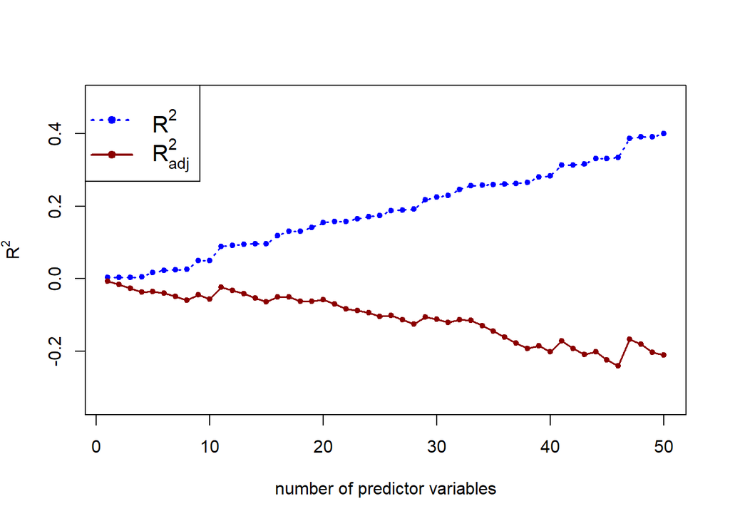

Figure 3: Extra graph about the first experiment.